# NAPED — Portfólio de Ações | Março 2026

[figure not shown]

Afya São João del Rei

Portfólio de Ações  
NAPED

Março de 2026

Registro das iniciativas desenvolvidas pelo Núcleo de Apoio Pedagógico e Experiência Docente.

Ação 1Março 2026

Capacitação Cultura Afya e Atendimento ao Público

Cultura Institucional e Atendimento Humanizado

Atividade formativa voltada ao alinhamento da equipe aos valores, diretrizes e práticas institucionais da Afya, com foco no fortalecimento da cultura organizacional e na qualificação do atendimento ao público.

Cultura institucional. Atendimento humanizado. Comunicação assertiva.

Evidências

Colaboradores Administrativos

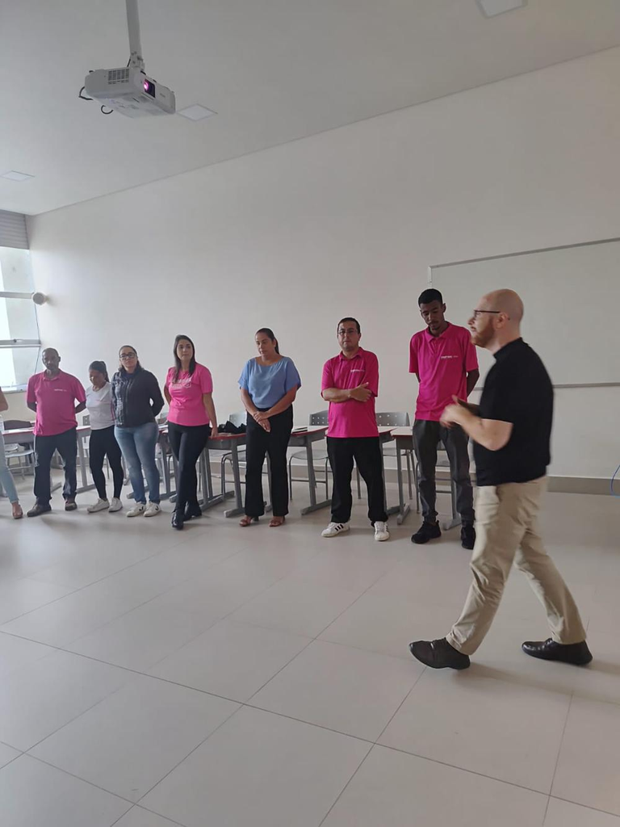

Capacitação — Colaboradores Administrativos

[figure not shown]

Capacitação — Colaboradores Administrativos

[figure not shown]

Capacitação — Colaboradores Administrativos

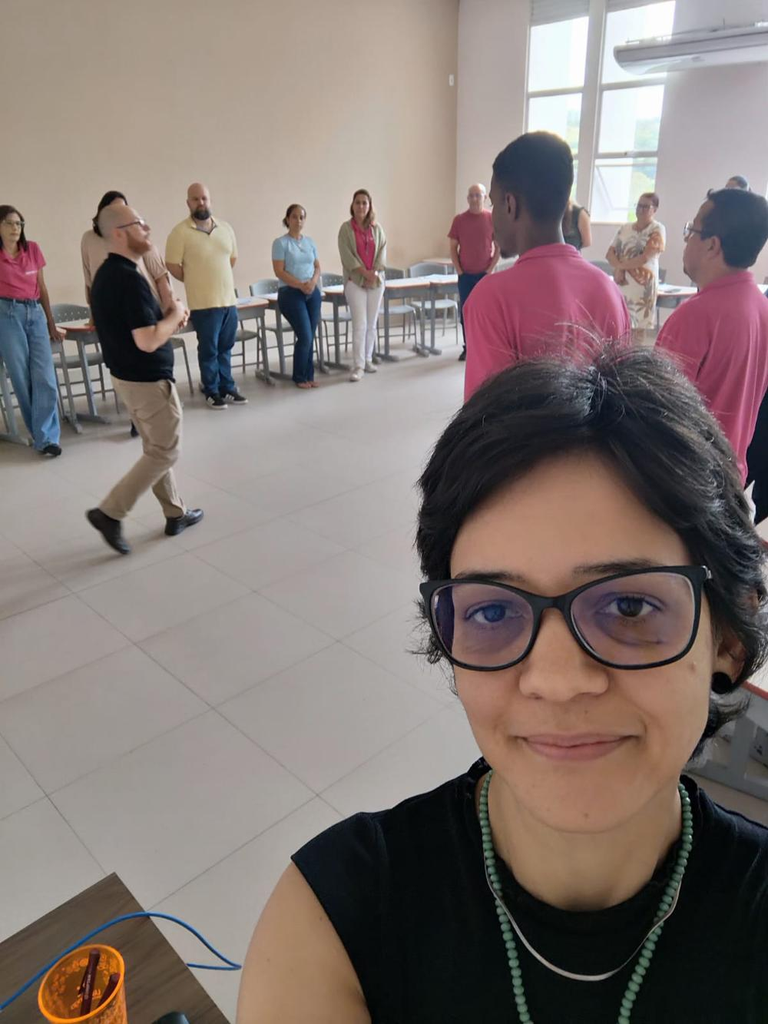

Capacitação — Colaboradores Administrativos

[figure not shown]

Capacitação — Colaboradores Administrativos

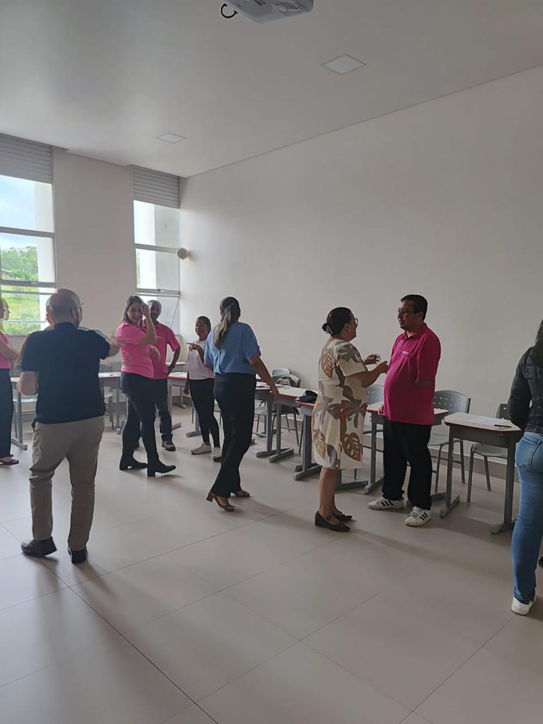

Capacitação — Colaboradores Administrativos

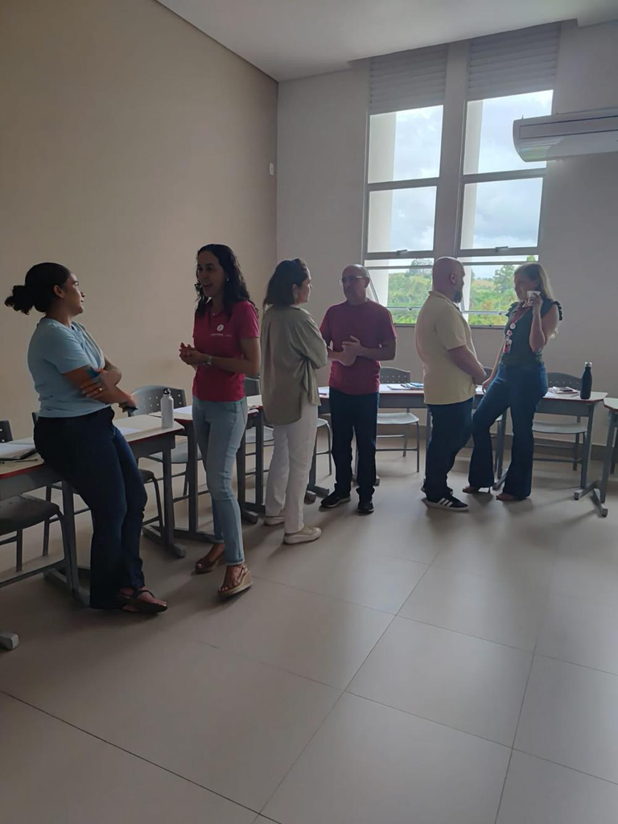

Capacitação — Colaboradores Administrativos

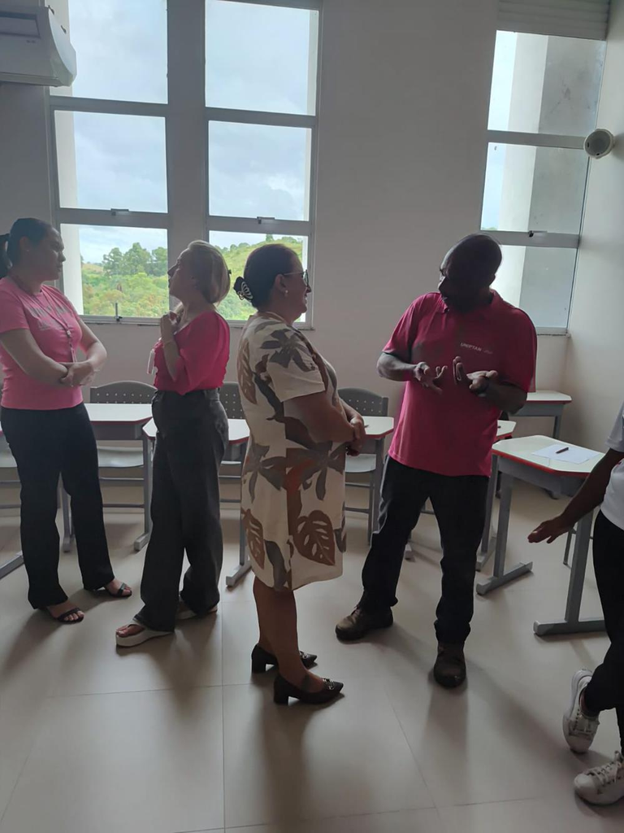

Capacitação — Colaboradores Administrativos

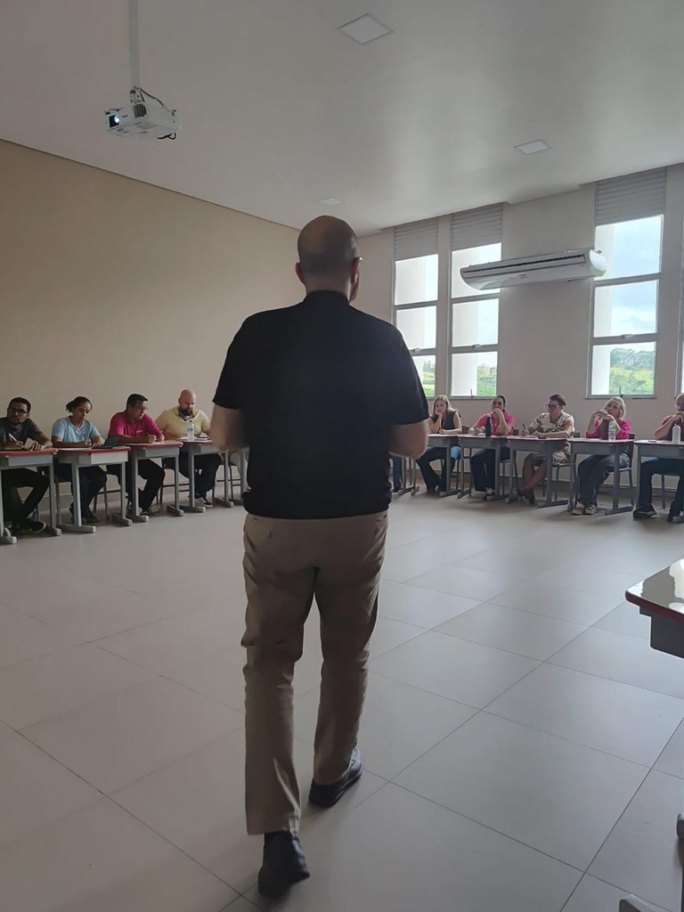

Capacitação — Colaboradores Administrativos

[figure not shown]

Capacitação — Colaboradores Administrativos

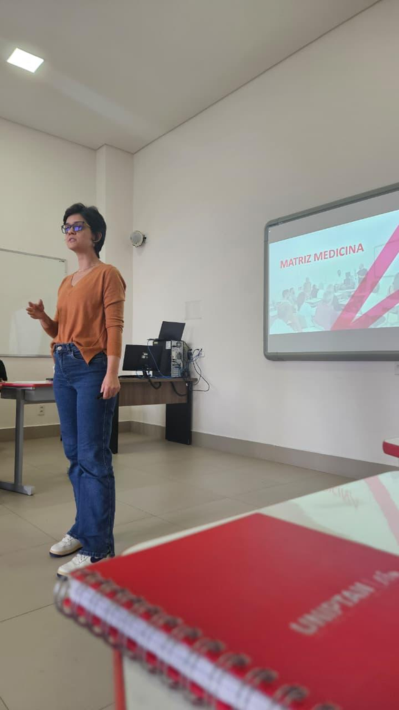

Capacitação — Colaboradores Administrativos

Funcionários Terceirizados

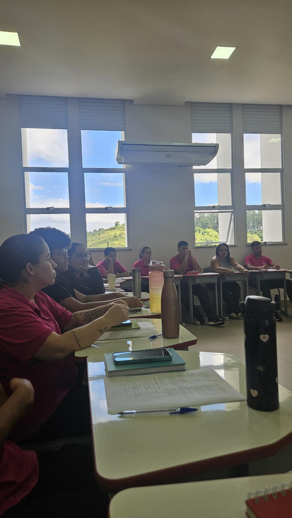

Capacitação — Funcionários Terceirizados

[figure not shown]

Capacitação — Funcionários Terceirizados

[figure not shown]

Capacitação — Funcionários Terceirizados

[figure not shown]

Capacitação — Funcionários Terceirizados

[figure not shown]

Capacitação — Funcionários Terceirizados

Ação 2Março 2026

Visita ao Internato Fora de Sede — Conselheiro Lafaiete

Acompanhamento de Campos de Prática

Visita de acompanhamento institucional às unidades de campo de prática do internato médico em Conselheiro Lafaiete, incluindo a UPA 24h Dr. Luiz de Souza Dias e o Hospital Queluz, com o objetivo de verificar a infraestrutura disponível e o acolhimento dos internos nesses cenários de aprendizagem.

Acompanhamento institucional, internato fora de sede, qualidade do campo de prática.

Evidências

[figure not shown]

UPA 24h Dr. Luiz de Souza Dias

Visita à unidade de pronto atendimento

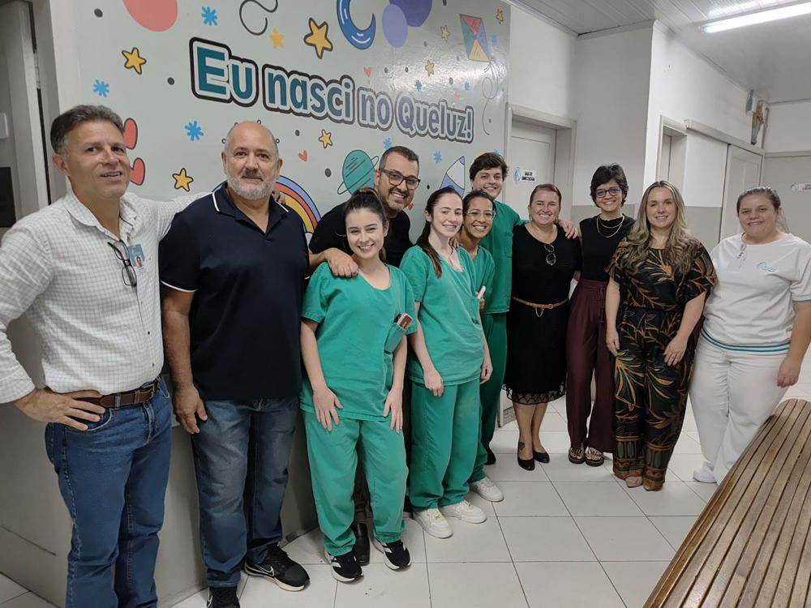

Hospital Queluz

Visita à maternidade e equipe do hospital

Ação 3Março 2026

Treinamento NotebookLM — Medicina

Ferramentas Digitais de Apoio ao Estudo

Treinamento oferecido pelo NAPED aos estudantes de Medicina na semana da N1, com cinco turmas em datas e horários distintos, realizado no Laboratório de Informática da instituição, com foco na utilização do NotebookLM como ferramenta de apoio à organização de materiais e otimização dos estudos.

NotebookLM, Medicina, semana da N1, laboratório de informática.

Evidências

[figure not shown]

Arte de divulgação — Treinamento NotebookLM

Datas: 30/03, 31/03, 01/04 às 18h; 08/04 e 09/04 às 10h — Laboratório de Informática, 3º andar

Ação 4Março 2026

Projeto ENAMED em Foco

Reunião com Alunos do Internato Fora de Sede & Oficina Test Wiseness

Reunião institucional realizada com os estudantes do internato fora de sede para apresentação do projeto "ENAMED em Foco", abordando o caráter obrigatório do exame, sua relação com a colação de grau e expedição de diploma, além do plano de ação do semestre: aulões diários de discussão de questões, aulas teóricas com casos clínicos e questões de revalida, feedback individual dos simulados pela equipe NED e cronograma de atividades da Jornada ENAMED.

ENAMED em Foco, internato fora de sede, plano de ação acadêmico.

Evidências

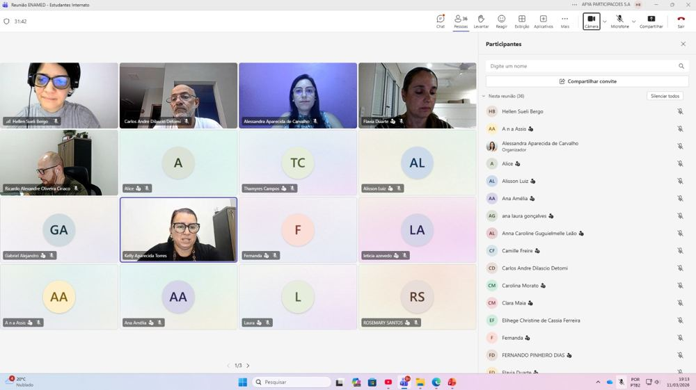

Reunião ENAMED — Estudantes Internato

Encontro com os estudantes do internato fora de sede

[figure not shown]

O Processo ENAMED e ENARE 2026

Apresentação institucional sobre o processo avaliativo

[figure not shown]

[figure not shown]

Reunião ENAMED — Estudantes Internato

Participação ampla dos estudantes do internato

Oficina Test Wiseness — Prof. Dr. Daniel Riani Gotardelo

Como desdobramento do projeto, foi realizada no dia 12 de março, às 17h, no Auditório da Afya São João del-Rei, a Oficina Test Wiseness, conduzida pelo Prof. Dr. Daniel Riani Gotardelo. O encontro ofereceu aos estudantes mais uma oportunidade de revisar estratégias de resolução de questões e fortalecer sua preparação para o ENAMED.

[figure not shown]

Divulgação — Oficina Test Wiseness

Convite aos estudantes: 12/03, às 17h, Auditório Afya SJ del-Rei

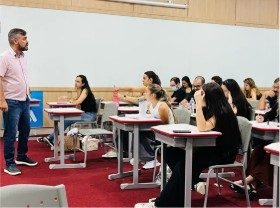

Oficina Test Wiseness

Prof. Dr. Daniel Riani Gotardelo conduzindo a oficina com os estudantes

[figure not shown]

Participação dos Estudantes

Momento de interação e revisão de estratégias para o exame

Ação 5Março 2026

Reunião do NAPED com Especialistas de Eixo e Coordenadora do NED

Construção do Memorial Docente

Reunião de alinhamento entre o NAPED, os especialistas de eixo e a coordenadora do NED, com foco na construção e padronização do memorial docente, fortalecendo a integração entre os setores e a qualidade da documentação pedagógica institucional.

Memorial docente, alinhamento institucional, especialistas de eixo.

Evidências

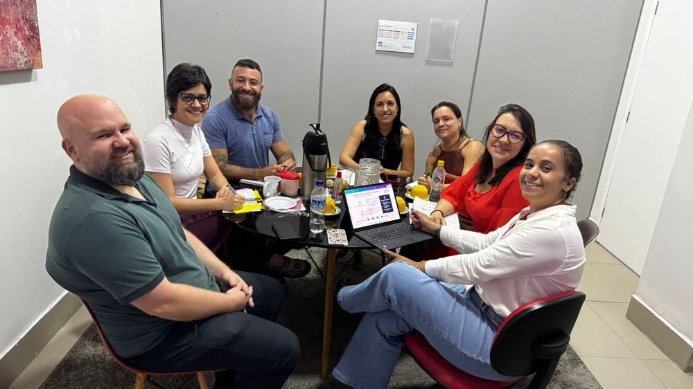

Reunião NAPED, especialistas de eixo e NED

Alinhamento para construção do memorial docente

[figure not shown]

Navegar pelo portfólio